# Class Assignments Solutions

R-L1 (December)

November 29, 2017

# Week-1 (Datatypes and Structures)

## Q1

From the **Match** dataset subset home_team_goal for only the stage 10 matches. What type of object is it ?

```r
# Subsetting Match dataset for only stage 10 matches

d1=subset(Match,stage==10)

# Fetching home team goal from the subsetted dataframe

d1$home_team_goal
```

```
##   [1]  4  1  0  0  2  1  0  1  1  3  0  2  1  1  1  2  2  4  1  1  4  2  0
##  [24]  3  2  1  2  3  2  1  0  1  1  2  4  3  1  1  1  1  0  0  4  0  2  2
##  [47]  3  0  2  2  0  2  0  1  2  3  1  1  3  0  1  3  0  2  5  5  5  0  1
##  [70]  4  3  4  0  2  1  0  1  1  3  1  2 10  1  3  2  3  3  4  0  1  1  1
##  [93]  1  1  1  1  2  0  1  2  1  6  0  1  2  1  1  4  1  3  2  1  6  2  2
## [116]  1  3  0  1  2  2  2  1  2  0  1  1  1  1  1  3  2  2  1  1  2  0  1
## [139]  0  1  1  1  1  2  0  1  2  5  2  1  0  4  3  1  0  3  1  1  1  0  0
## [162]  3  0  2  2  1  1  0  2  0  1  1  0  2  2  1  3  0  1  1  1  1  2  2
## [185]  4  1  2  2  3  1  1  0  2  1  1  2  2  2  1  0  1  1  2  1  0  1  1
## [208]  2  0  1  2  5  2  1  2  3  0  1  2  2  3  0  1  2  1  3  0  3  1  2
## [231]  2  2  2  0  2  1  1  0  3  0  1  0  1  1  1  2  2  3  0  1  1  1  0
## [254]  2  2  0  3  2  1  0  2  4  2  1  1  1  1  0  0  3  1  2  3  1  1  0
## [277]  0  0  2  4  1  2  2  1  1  1  1  1  3  2  0  1  1  1  2  2  4  1  3
## [300]  1  0  1  0  1  2  1  1  3  1  1  1  2  1  0  2  4  6  0  3  2  3  0
## [323]  1  0  2  0  4  2  3  3  2  1  4  1  2  3  1  1  1  2  1  1  3  3  3
## [346]  2  0  2  0  1  0  0  2  2  1  0  4  1  3  4  0  0  5  3  0  2  2  0
## [369]  3  0  4  1  2  1  1  2  0  0  2  1  0  2  3  2  3  1  1  1  1  1  1
## [392]  1  1  3  4  4  3  1  4  1  1  1  2  1  1  1  0  0  2  4  2  0  2  0
## [415]  2  0  0  1  2  1  2  2  1  1  3  1  1  0  0
```

```r
# Object type

class(d1$home_team_goal)
```

```
## [1] "integer"
```

## Q2

In the **Match** dataset what is the type of column **date** ? Convert the column into date type object.

```r
# Checking the class of the date column

class(Match$date)
```

```
## [1] "character"
```

```r
# We see the date column is character type, Lets convert it to date.

Match$date=as.Date(Match$date,format = "%m/%d/%Y")

class(Match$date)
```

```
## [1] "Date"
```

## Q3

```r
# Way 1

Team_Attributes[Team_Attributes$buildUpPlaySpeed>60 & Team_Attributes$buildUpPlayPassing>65,]
```

```
##      id team_fifa_api_id team_api_id      date buildUpPlaySpeed
## 54  318              192        8533 9/10/2015               66
## 58  341             1799        9826 9/10/2015               61
## 88  496           110556       10233 9/10/2015               64
## 140 818             1893       10212 9/10/2015               61
## 171 988           111086        8028 9/10/2015               64
## 172 992           111087        8033 9/10/2015               68
##     buildUpPlayDribbling buildUpPlayPassing buildUpPlayPositioningClass
## 54                    54                 67                   Organised
## 58                    45                 67                   Organised
## 88                    52                 68                   Organised
## 140                   49                 66                   Organised
## 171                   52                 67                   Organised
## 172                   55                 66                   Organised
##     chanceCreationPassing chanceCreationCrossing chanceCreationShooting
```

[output cut: 20 more lines]

```r
# Way 2

subset(Team_Attributes,Team_Attributes$buildUpPlaySpeed>60 & Team_Attributes$buildUpPlayPassing>65)
```

```
##      id team_fifa_api_id team_api_id      date buildUpPlaySpeed
## 54  318              192        8533 9/10/2015               66
## 58  341             1799        9826 9/10/2015               61
## 88  496           110556       10233 9/10/2015               64
## 140 818             1893       10212 9/10/2015               61
## 171 988           111086        8028 9/10/2015               64
## 172 992           111087        8033 9/10/2015               68
##     buildUpPlayDribbling buildUpPlayPassing buildUpPlayPositioningClass
## 54                    54                 67                   Organised
## 58                    45                 67                   Organised
## 88                    52                 68                   Organised
## 140                   49                 66                   Organised
## 171                   52                 67                   Organised
## 172                   55                 66                   Organised
##     chanceCreationPassing chanceCreationCrossing chanceCreationShooting
```

[output cut: 20 more lines]

# Week-2 (apply family)

## Q1

For the **Team Attributes** datasets first subset the columns of type numeric and then find out teir maximum.

```r
# Finding out the numeric columns

sapply(Team_Attributes,FUN = class)
```

```
##                             id               team_fifa_api_id
##                      "integer"                      "integer"
##                    team_api_id                           date
##                      "integer"                       "factor"
##               buildUpPlaySpeed           buildUpPlayDribbling
##                      "integer"                      "integer"
##             buildUpPlayPassing    buildUpPlayPositioningClass
##                      "integer"                       "factor"
##          chanceCreationPassing         chanceCreationCrossing
##                      "integer"                      "integer"
##         chanceCreationShooting chanceCreationPositioningClass
##                      "integer"                       "factor"
##                defencePressure              defenceAggression
##                      "integer"                      "integer"
##               defenceTeamWidth       defenceDefenderLineClass
##                      "integer"                       "factor"
```

```r
# Subsetting the Dataframe according to column class

d2=Team_Attributes[,sapply(Team_Attributes,FUN = class)=="integer"]

# Finding out their maximum

apply(d2,2,max)
```

```
##                     id       team_fifa_api_id            team_api_id
##                   1458                 112513                 274581
##       buildUpPlaySpeed   buildUpPlayDribbling     buildUpPlayPassing
##                     80                     77                     77
##  chanceCreationPassing chanceCreationCrossing chanceCreationShooting
##                     77                     80                     80
##        defencePressure      defenceAggression       defenceTeamWidth
##                     72                     72                     73
```

## Q2

From the **Match** dataset find out the average number of goal scored per stage.

```r
# Way 1

aggregate(cbind(home_team_goal,away_team_goal)~stage,Match,mean)
```

```
##    stage home_team_goal away_team_goal
## 1      1       1.424242       1.107226
## 2      2       1.582751       1.212121
## 3      3       1.478571       1.192857
## 4      4       1.606977       1.134884
## 5      5       1.390698       1.172093
## 6      6       1.539535       1.109302
## 7      7       1.583721       1.127907
## 8      8       1.690698       1.179070
## 9      9       1.413953       1.172093
## 10    10       1.554779       1.240093
## 11    11       1.615385       1.125874
## 12    12       1.533800       1.090909
## 13    13       1.473193       1.268065
## 14    14       1.613054       1.247086
```

[output cut: 24 more lines]

```r
# Way 2

aggregate(cbind(home_goal=Match$home_team_goal,away_goal=Match$away_team_goal),list(Stage=Match$stage),mean)
```

```
##    Stage home_goal away_goal
## 1      1  1.424242  1.107226
## 2      2  1.582751  1.212121
## 3      3  1.478571  1.192857
## 4      4  1.606977  1.134884
## 5      5  1.390698  1.172093
## 6      6  1.539535  1.109302
## 7      7  1.583721  1.127907
## 8      8  1.690698  1.179070
## 9      9  1.413953  1.172093
## 10    10  1.554779  1.240093
## 11    11  1.615385  1.125874
## 12    12  1.533800  1.090909
## 13    13  1.473193  1.268065
## 14    14  1.613054  1.247086
```

[output cut: 24 more lines]

```r
# Way 3

cbind(tapply(Match$away_team_goal,Match$stage,mean),
      tapply(Match$away_team_goal,Match$stage,mean))
```

```
##        [,1]     [,2]
## 1  1.107226 1.107226
## 2  1.212121 1.212121
## 3  1.192857 1.192857
## 4  1.134884 1.134884
## 5  1.172093 1.172093
## 6  1.109302 1.109302
## 7  1.127907 1.127907
## 8  1.179070 1.179070
## 9  1.172093 1.172093
## 10 1.240093 1.240093
## 11 1.125874 1.125874
## 12 1.090909 1.090909
## 13 1.268065 1.268065
## 14 1.247086 1.247086
```

[output cut: 24 more lines]

# Week-3 (Sort,Merge,Reshape,Loops)

In The **Match** dataset include the **home_team_name** and **away_team_name** from the **Team** dataset.

```r
# Merging by home team id

library(reshape2)
d3=merge(x=Team[,c(2,4)],y = Match[,-c(2,3,7)],by.y= "home_team_api_id",by.x = "team_api_id")

# Merging away team id

d4=merge(x=Team[,c(2,4)],y = d3,by.y= "away_team_api_id",by.x = "team_api_id",suffixes = c("_home","_away"))
# Snapshot of Resultant dataset
head(d4[,c(2,4,6,8,9,10)])
```

```
##   team_long_name_home team_long_name_away    season       date
## 1        Ruch Chorzów       Slask Wroclaw 2015/2016 2016-03-19
## 2        Ruch Chorzów            Cracovia 2010/2011 2010-10-17
## 3        Ruch Chorzów         Widzew Lódz 2013/2014 2013-09-25
## 4        Ruch Chorzów      Zaglebie Lubin 2013/2014 2013-12-15
## 5        Ruch Chorzów       Lechia Gdansk 2010/2011 2010-08-08
## 6        Ruch Chorzów      Odra Wodzislaw 2009/2010 2009-10-03
##   home_team_goal away_team_goal
## 1              0              0
## 2              2              3
## 3              0              1
## 4              1              2
## 5              0              0
## 6              1              3
```

## Q2

Sort the **Team_attributes** dataset acoording to Increasing order of defencePressure and descending order of chanceCreationCrossing.

```r
d5=Team_Attributes[with(Team_Attributes,order(defencePressure,-chanceCreationCrossing)),]

# snapshot of the result
head(d5[,c(1,4,10,13)])
```

```
##       id      date chanceCreationCrossing defencePressure
## 39   236 9/10/2015                     65              25
## 163  955 9/10/2015                     48              25
## 47   276 9/10/2015                     40              25
## 88   496 9/10/2015                     45              27
## 231 1366 9/10/2015                     42              27
## 86   484 9/10/2015                     54              29
```

## Q3

Melt the **Team_Attributes** dataset with id variable **chanceCreationPositioningClass** and measure variable **defencePressure defenceAggression**. Then find out the average value of **defencePressure defenceAggression** corresponding to each **chanceCreationPositioningClass** .

```r
d6=melt(data = Team_Attributes,
        id.vars="chanceCreationPositioningClass",
        measure.vars=c("defencePressure","defenceAggression"))

# Snapshot

head(d6)
```

```
##   chanceCreationPositioningClass        variable value
## 1                      Organised defencePressure    47
## 2                      Free Form defencePressure    49
## 3                      Organised defencePressure    38
## 4                      Organised defencePressure    58
## 5                      Organised defencePressure    39
## 6                      Organised defencePressure    40
```

```r
tail(d6)
```

```
##     chanceCreationPositioningClass          variable value
## 485                      Organised defenceAggression    46
## 486                      Organised defenceAggression    48
## 487                      Organised defenceAggression    34
## 488                      Organised defenceAggression    43
## 489                      Organised defenceAggression    47
## 490                      Organised defenceAggression    58
```

```r
# Way 1
d6_d=dcast(data = d6,formula=chanceCreationPositioningClass ~ variable,mean)
head(d6_d)
```

```
##   chanceCreationPositioningClass defencePressure defenceAggression
## 1                      Free Form        51.34615          53.84615
## 2                      Organised        44.98174          48.23288
```

```r
# Way 2
d6_a=acast(data = d6,formula=chanceCreationPositioningClass ~ variable,mean)
head(d6_a)
```

```
##           defencePressure defenceAggression
## Free Form        51.34615          53.84615
## Organised        44.98174          48.23288
```

## Q4

In the **Match** dataset find out the games for which Bet365 home win odds were less than away win odds.

```r
d7=na.omit(Match)
for(i in 1:nrow(d7))
 {
  #print(i)
  if(d7$B365H[i]<d7$B365A[i])
  {
    d7[i,15]="Hit"
    }else
      d7[i,15]="No Hit"
  }
head(d7[,c(1,10,11,12,14,15)])
```

```
##   id home_team_goal away_team_goal B365H B365A    V15
## 1  1              1              1  1.73  5.00    Hit
## 2  2              0              0  1.95  3.60    Hit
## 3  3              0              3  2.38  2.75    Hit
## 4  4              5              0  1.44  7.50    Hit
## 5  5              1              3  5.00  1.65 No Hit
## 6  6              1              1  4.75  1.67 No Hit
```

# Week-4 (User Defined Function)

## Q1

Write a function for mode, and find out the mode for every column in **Team_Attributes** dataset.

```r
My_mode <- function(x)
  {
   nx = na.omit(x)
   ux = unique(nx)
   ux[which.max(tabulate(match(x, ux)))]
  }

apply(Team_Attributes[,-c(1,2,3)],2,My_mode)
```

```
##                           date               buildUpPlaySpeed
##                    "9/10/2015"                           "48"
##           buildUpPlayDribbling             buildUpPlayPassing
##                           "52"                           "52"
##    buildUpPlayPositioningClass          chanceCreationPassing
##                    "Organised"                           "49"
##         chanceCreationCrossing         chanceCreationShooting
##                           "53"                           "53"
## chanceCreationPositioningClass                defencePressure
##                    "Organised"                           "47"
##              defenceAggression               defenceTeamWidth
##                           "47"                           "52"
##       defenceDefenderLineClass
##                        "Cover"
```

## Q2

Write a function which takes an numeric vector as inpute, and creates buckets according to quantiles.

```r
My_bin=function(x,cut=c(0.25,0.50,0.75))
 {
  Bin=ifelse(x<quantile(x,cut[1]),"Bucket_1",
           ifelse(x>quantile(x,cut[1]) & x<=quantile(x,cut[2]),"Bucket_2",
                  ifelse(x>quantile(x,cut[2]) & x<=quantile(x,cut[3]),"Bucket_3",
                         "Bucket_4")))
  return(cbind(x,Bin))
 }
My_bin(rnorm(10,0,4))
```

```
##       x                    Bin
##  [1,] "3.98620899861667"   "Bucket_4"
##  [2,] "-0.456303047233811" "Bucket_2"
##  [3,] "-1.96570822225928"  "Bucket_2"
##  [4,] "-6.17756131654907"  "Bucket_1"
##  [5,] "-3.68459496341316"  "Bucket_1"
##  [6,] "-2.73153886017841"  "Bucket_1"
##  [7,] "0.251574191621699"  "Bucket_3"
##  [8,] "4.22344478619907"   "Bucket_4"
##  [9,] "1.17588718592434"   "Bucket_4"
## [10,] "1.04682581936858"   "Bucket_3"
```

# Plots

## Q1

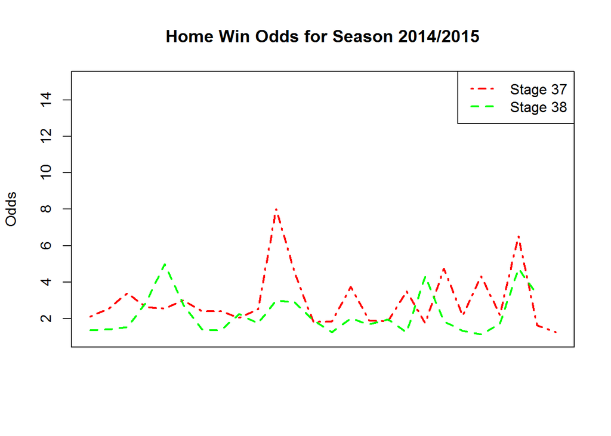

```r
plot(na.omit(Match$B365H[Match$stage==37 & Match$season=="2014/2015"]),
     cex=0.3,type="l",col="red",ylim=c(1,15),lty=4,lwd=2,
     main="Home Win Odds for Season 2014/2015",ylab="Odds",xlab="",xaxt="n")
points(na.omit(Match$B365H[Match$stage==38 & Match$season=="2014/2015"]),
       cex=0.3,type="l",col="green",lty=2,lwd=2)
legend("topright",legend = c("Stage 37","Stage 38" ),
       col=c("red","green"),lty = c(4,2),lwd=2)
```